## Distributional functions in R

In R [probability distributions](https://en.wikipedia.org/wiki/Probability_distribution) functions have a common naming convention. And since distributions is one of the main tools in statistics it is important to know this framework.

If for instance we are interested in the property of a standard normal random variable, $X$, i.e. a random variable with [normal distrbution](https://en.wikipedia.org/wiki/Normal_distribution) with mean zero and variance one, then in R one should look for functions conncted to `norm`. If we want to compute the probability that $X$ is less or equal to two ($\mathbb{P}(X < 2$) then one uses the function `pnorm`; If one want to find the $x$ where the probability that $X$ is less then a half then one uses `qnorm`; If one wants to know the density of for a value one uses `dnorm`; Finnaly we if want to generate a random number that follows the normal distribution we use `rnorm`.

In R any distributional object should have the same structure, that is for a generic distribution *dens* we have

- `d` density
- `p` probability
- `q` quantile
- `r` random number

We will now go through the functions one by one and also give a short reminder of the definition of each of them.

## Probability function

Here we want to compute the probability of $\mathbb{P}(X \leq x)$ where $X$ has a known distribution. This function is also known as the [cumulative distribution function (CDF)](https://en.wikipedia.org/wiki/Cumulative_distribution_function), often denoted $F(x)=\mathbb{P}(X \leq x)$. The general function of `p` has the following arguments

```r
p(x, parameter1, paramater2, ..., lower.tail=TRUE, log.p=FALSE)
```

That is `x` is the value we want to compute that the probability is less or equal; `parameter1, parameter2` are the parameters for the specific distribution; `lower.tail=TRUE` means we compute $\mathbb{P}(X\leq x)$ if `lower.tail=FALSE` one instead computes $\mathbb{P}(X> x)$. If `log.p=TRUE` the function returns $\log\left( \mathbb{P}(X\leq x) \right)$ this can be useful if dealing with very small proabilites as there can be round off errors.

#### Example

Suppose that $X$ follows a Poisson distribution with intensity $\lambda=4$ (a parameter), which equivalently can be written
$$X \sim Poiss(\lambda=4).$$
Then to compute the probability that $\mathbb{P}(X \leq 4)$ in R we use

```r
Ple4 <- ppois(4, lambda = 4)
print(round(Ple4,2))
```

```
## [1] 0.63
```

To get the probability of $\mathbb{P}(X > 4)$ we can use that
$$\mathbb{P}(X > 4)= 1- \mathbb{P}(X \leq 4) \approx 1- 0.63 = 0.37$$
or in R

```r
Pg4 <- ppois(4, lambda = 4, lower.tail=F)
print(round(Pg4,2))
```

```
## [1] 0.37
```

To compute the probability of $\mathbb{P}(2 < X <10) = \mathbb{P}(X < 10) - \mathbb{P}(X \leq 2 )$ which for a the Poisson distribution gives (since the Poisson distribution is a discrete distribution).

```r
Pl10 <- ppois(9, lambda = 4)
Pl2   <- ppois(2, lambda = 4)
print(round(Pl10-Pl2,2))
```

```
## [1] 0.75
```

Make sure you understand why one used `x=9` and `x=2`.

If we instead $X$ follows a Normal distribution with mean two and variance 3, often denoted $X \sim \mathcal{N}\left(2,3 \right)$ then

```r
Pl10 <- pnorm(10,  mean = 2, sd = sqrt(3))
Pl2   <- pnorm(2, mean = 2, sd = sqrt(3))
print(round(Pl10-Pl2,2))
```

```
## [1] 0.5
```

Make sure you understand why one used `x=10` and `x=2`. For more detail see [Wikit on probability distribution](https://en.wikipedia.org/wiki/Probability_distribution).

## Density function

Here we want to compute [the density function](https://en.wikipedia.org/wiki/Probability_density_function) where $X$ has a known distribution. Recall that density function for a random variable is the non-negative function $f$ such that
$$\mathbb{P}\left(X \leq x \right) = \int^x f(s) ds.$$
For a discrete random variable one gets
$$\mathbb{P}\left(X \leq x \right) = \sum_{i:x_i \leq x} f(x_i) = \sum_{i:x_i \leq x} \mathbb{P}(X=x_i).$$
The general function of `d` has the following arguments

```r
d(x, parameter1, paramater2, ...,log=FALSE)
```

where `log=TRUE` returns the natural logarithm of the density.

Note that any non-negative function, $f$, taking values such that
$$\int_D f(s) ds< \infty$$
can be transformed to a density on $D$ by
$$\tilde{f}(x) = \frac{f(x)}{\int_D f(s) ds}.$$
What is the value of $\int_D \tilde{f}(s) ds$? For more details on the density function see [wiki](https://en.wikipedia.org/wiki/Probability_density_function)

#### Example

If $X$ is a Poisson random variable with $\lambda=4$ then to compute $\mathbb{P}\left(X=4 \right)$ one uses:

```r
Ple4 <- dpois(4, lambda = 4)
print(round(Ple4,2))
```

```
## [1] 0.2
```

To link `dpois` and `ppois` note that:

```r
Ple4 <- ppois(4, lambda = 4, lower.tail=T)
Ple4.v2 <- sum(dpois(0:4, lambda=4))
print(round(Ple4-Ple4.v2,2))
```

```
## [1] 0
```

To compute $\mathbb{P}\left( 2<X < 10\right)$ for $X \sim \mathcal{N}\left(2,3 \right)$ using `dnorm` we use the `integrate` function:

```r
Pg2l10 <- integrate(function(x){dnorm(x,2,sqrt(3))},2,10)
print(round(Pg2l10$value,2))
```

```
## [1] 0.5
```

## Quantile function

The function `q` is the [quantile function](https://en.wikipedia.org/wiki/Quantile_function), this function takes a probability $p$ and finds the value $x$ such that
$$\mathbb{P}(X \leq x) = p.$$
This can be written in the more complicated form
$$Q(p) = inf \{x: p \leq F(x) \}= F^{-1}(x).$$
Recall that $F(x) = \mathbb{P}\left(X \leq x \right)$ , and it follows that if $F$ is continuous then $F(F^{-1}(p))=p$. The general function of `q` has the following arguments

```r
q(p, parameter1, paramater2, ...,lower.tail=TRUE,log.p=FALSE).
```

Note that if $X$ is a discrete random variable there might not exits and $x$ such that $\mathbb{P}(X \leq x) = p$, in this case one takes the smallest $x$ s.t $\mathbb{P} \left( X \leq x \right) \geq p$.

#### Example

If $X$ is a Poisson random variable with $\lambda=4$ then to find the smallest such that$x$ $\mathbb{P}\left(X \leq x \right)=0.2$ one uses:

```r
Ql02 <- qpois(0.2, lambda = 4)
print(round(Ql02,2))
```

```
## [1] 2
```

```r
Qg07 <- qnorm(0.7, mean = 4, sd = sqrt(3), lower.tail = FALSE)
print(round(Qg07,2))
```

```
## [1] 3.09
```

For lower tail one can use the following relation

```r
Qg07.v2<- qnorm(1-0.7, mean = 4, sd = sqrt(3), lower.tail = TRUE)
print(round(Qg07-Qg07.v2,2))
```

```
## [1] 0
```

## random number generation

To simulate random number from the a distribution one uses the function `r`

```r
r(n, parameter1, paramater2,...).
```

here `n` is the number of samples one wants to generate.

#### Example

To sample ten random variables from a Poisson distribution with $\lambda=4$ one uses

```r
X <- rpois(n=10, lambda = 4)
print(X)
```

```
##  [1] 2 4 8 2 2 4 1 2 5 4
```

If one can has the quantile function, $q$ for a random variable and can generate samples from a uniform distribution then one can generate samples from the distrbution using the [inverse method](https://en.wikipedia.org/wiki/Inverse_transform_sampling):

```r
U <- runif(10) # samples from U ~ U[0,1]
X <- qpois(U, lambda=4)
print(X)
```

```
##  [1] 3 4 4 3 6 3 4 8 6 3
```

To see the connection between histogram of a random variable and it density one can use

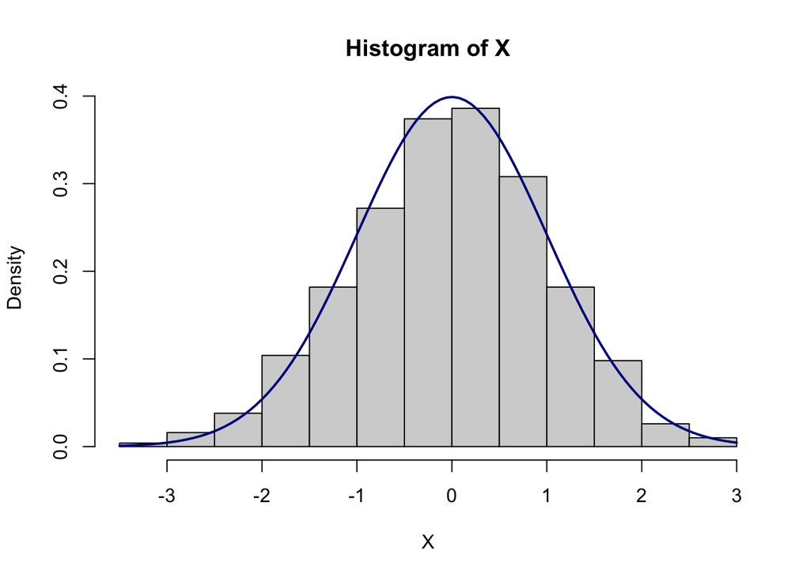

```r
X <- rnorm(n=1000) # samples from U ~ U[0,1]
hist(X, prob=TRUE)
curve(dnorm, col="darkblue", lwd=2, add=TRUE, yaxt="n")
```

To verify the [inverse method](https://en.wikipedia.org/wiki/Inverse_transform_sampling):

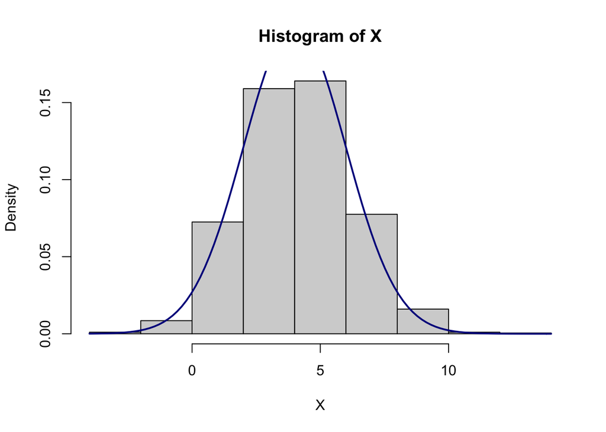

```r
X <- qnorm(runif(n=1000), mean=4,sd=2) # samples from U ~ U[0,1]
hist(X, prob=TRUE)
curve(dnorm(x, mean=4, sd=2), col="darkblue", lwd=2, add=TRUE, yaxt="n")
```